# evolution

Author

Olaf König

```r
# Data manipulation
library(tidyverse)
library(readr)
library(readxl)

# Data visualization
library(ggplot2)

# Utility
library(here)
library(janitor)

# Custom theme for plots
theme_set(theme_minimal())

# Disable scientific notation
options(scipen = 999)
# # Re-enable scientific notation (default behavior)
# options(scipen = 0)
```

```r
# Define project paths
input_raw_dir <- here("input", "raw")
input_processed_dir <- here("input", "processed")
output_dir <- here("output")
```

## 1 Import des datasets

```r
df_evo <- read.csv(file.path(input_processed_dir, "students_entries_2015_2025_cantons.csv")) |>
  select(-X)


df_evo_ch <- df_evo |>
  group_by(sex, metric, year) |>
  summarise(
    value = sum(value, na.rm = TRUE)
  )  |>
    ungroup() |>
    arrange(year)  |>
    group_by(sex, metric) |>
    mutate(
      index = (value / first(value) * 100) -100
    )
```

### 1.1 Import Cubes

https://www.pxweb.bfs.admin.ch/pxweb/fr/px-x-1502040100_104/px-x-1502040100_104/px-x-1502040100_104.px/table/tableViewLayout2/ **Cube does not offer same figures than Excel Sheets….**

```r
# get_px <- function(url, chemin_local, nom_fichier) {
#   # Construire le chemin complet pour le fichier local
#   chemin_complet <- file.path(chemin_local, nom_fichier)

#   # Créer le répertoire local s'il n'existe pas
#   if (!dir.exists(chemin_local)) {
#     dir.create(chemin_local, recursive = TRUE)
#   }

#   # Télécharger le fichier depuis l'URL et l'enregistrer localement
#   download.file(url, destfile = chemin_complet, mode = "wb")

#   # Vérifier si le fichier a été correctement téléchargé
#   if (file.exists(chemin_complet)) {
#     message("Téléchargement réussi : ", chemin_complet)

#     # Lire et convertir l'encodage du fichier en UTF-8
#     lignes <- readLines(chemin_complet, encoding = "Windows-1252")
#     lignes_utf8 <- iconv(lignes, from = "Windows-1252", to = "UTF-8")

#     # Écrire les lignes converties dans le même fichier avec encodage UTF-8
#     writeLines(lignes_utf8, file(chemin_complet, encoding = "UTF-8"))
#     message("Encodage converti en UTF-8.")

#   } else {
#     message("Échec du téléchargement.")
#   }
# }


#------------- Utilisation de la fonction------------
url <- "https://www.pxweb.bfs.admin.ch/sq/005df392-424f-451d-9124-e2acbf2a93d2"
chemin_local <- input_raw_dir
nom_fichier <- "px_students_foreigners.csv"

# get_px(url, chemin_local, nom_fichier)

df_students_foreigners <- read_csv(file.path(chemin_local, nom_fichier)) %>%
janitor::clean_names()
```

#### 1.1.1 PX agrégat au niveau national

```r
df_students_foreigners_long <- df_students_foreigners |>
  mutate(year = as.numeric(substr(annee, 1, 4))) |>
  pivot_longer(
    cols = bs:ethz,
    names_to = "institution",
    values_to = "value"
  )

df_students_foreigners_ch <- df_students_foreigners_long |>
  group_by(annee, nationalite_categorie) |>
  summarise(value = sum(value), .groups = "drop") |>
  mutate(year = as.numeric(substr(annee, 1, 4))) |>
  group_by(annee, year) |>
  mutate(
    total = sum(value),
    pct = 100 * value / total
  ) |>
  ungroup()
```

### 1.2 Graphique suisse vs Etranger National

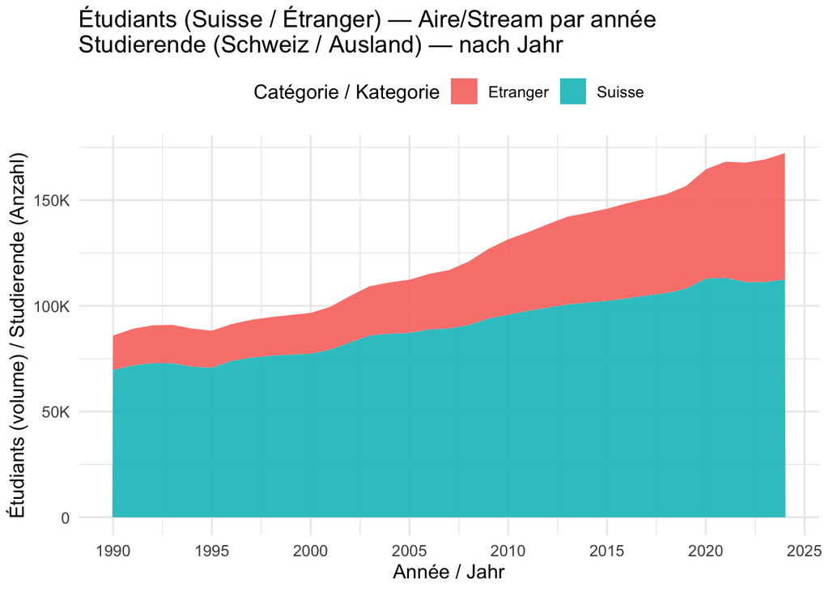

```r
library(ggplot2)
library(scales)

# Choisit automatiquement le nouvel équivalent "k / M" si dispo
label_short <- tryCatch(
  scales::label_number(scale_cut = scales::cut_short_scale()),
  error = function(e) scales::label_number()
)

p_stream_vol <- ggplot(
  df_students_foreigners_ch,
  aes(x = year, y = value, fill = nationalite_categorie)
) +
  geom_area(position = "stack", alpha = 0.9) +  # ou geom_stream(...) si tu as ggstream
  scale_x_continuous(breaks = pretty(df_students_foreigners_ch$year)) +
  scale_y_continuous(labels = label_short) +
  labs(
    title = "Étudiants (Suisse / Étranger) — Aire/Stream par année\nStudierende (Schweiz / Ausland) — nach Jahr",
    x = "Année / Jahr",
    y = "Étudiants (volume) / Studierende (Anzahl)",
    fill = "Catégorie / Kategorie"
  ) +
  theme_minimal(base_size = 12) +
  theme(legend.position = "top")

p_stream_vol
```

#### 1.2.1 DW Graphique Suisse vs étrangers

https://app.datawrapper.de/tamedia/edit/c5sxp/upload

```r
dw_students_foreigners <- df_students_foreigners_ch |>
  select(-pct, - total, -annee) |>
  pivot_wider(
    names_from = nationalite_categorie,
    values_from = value
  ) |> select(
    year, Suisse, Etranger
  )

dw_students_foreigners |>
  DatawRappr::dw_data_to_chart("c5sxp")
```

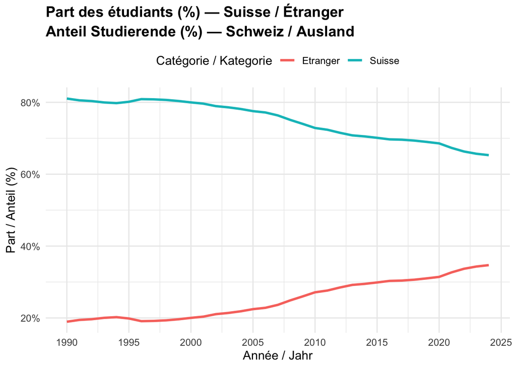

```r
ggplot(
  df_students_foreigners_ch,
  aes(x = year, y = pct, color = nationalite_categorie, group = nationalite_categorie)
) +
  geom_line(linewidth = 1.1) +
  scale_y_continuous(labels = scales::label_percent(scale = 1)) +
  scale_x_continuous(breaks = pretty(df_students_foreigners_ch$year)) +
  labs(
    title = "Part des étudiants (%) — Suisse / Étranger\nAnteil Studierende (%) — Schweiz / Ausland",
    x = "Année / Jahr",
    y = "Part / Anteil (%)",
    color = "Catégorie / Kategorie"
  ) +
  theme_minimal(base_size = 12) +
  theme(
    legend.position = "top",
    plot.title = element_text(face = "bold", lineheight = 1.1)
  )
```

### 1.3 Graphique suisse vs Etranger par institution

Clé pour les noms

```r
library(tibble)

institutions <- tribble(
  ~institution, ~nom_fr, ~nom_de,
  "BE",       "Université de Berne",                       "Universität Bern",
  "BS",       "Université de Bâle",                        "Universität Basel",
  "EPFL",     "École polytechnique fédérale de Lausanne",  "École polytechnique fédérale de Lausanne (EPFL)",
  "ETHZ",     "École polytechnique fédérale de Zurich",    "Eidgenössische Technische Hochschule Zürich (ETHZ)",
  "FR",       "Université de Fribourg",                    "Universität Freiburg",
  "FS_CH",    "Formation universitaire à distance Suisse", "FernUni Schweiz",
  "GE",       "Université de Genève",                      "Universität Genf",
  "IHEID",    "Institut de hautes études internationales et du développement",
               "Graduate Institute of International and Development Studies (IHEID)",
  "IUKB",     "Institut universitaire Kurt Bösch",         "Universitäres Institut Kurt Bösch",
  "LS",       "Université de Lausanne",                    "Universität Lausanne",
  "LU",       "Université de Lucerne",                     "Universität Luzern",
  "NE",       "Université de Neuchâtel",                   "Universität Neuenburg",
  "SG",       "Université de Saint-Gall",                  "Universität St. Gallen",
  "PHSG_UI",  "Haute école pédagogique de Saint-Gall",     "Pädagogische Hochschule St. Gallen",
  "TH_CHUR",  "Haute école de théologie de Coire",         "Theologische Hochschule Chur",
  "USI",      "Université de la Suisse italienne",         "Università della Svizzera italiana (USI)",
  "UZH",      "Université de Zurich",                      "Universität Zürich",
  "TOTAL",    "Total",                                     "Total"
)
```

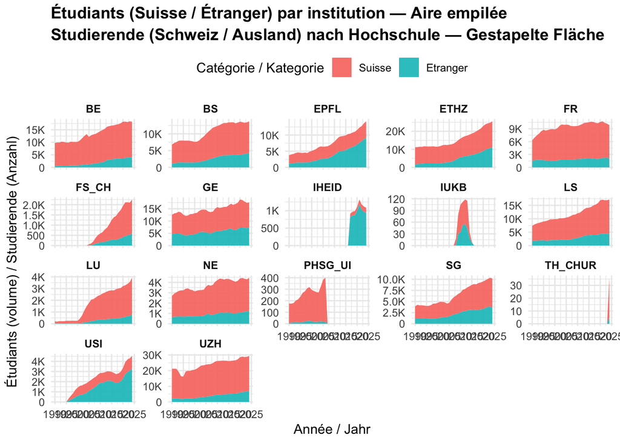

```r
library(ggplot2)
library(scales)

# Nettoyage / ordre facultatif
df_students_foreigners_long <- df_students_foreigners_long |>
  mutate(
    nationalite_categorie = factor(
      nationalite_categorie,
      levels = c("Suisse", "Etranger")
    ),
    institution = toupper(institution) # si tu veux homogénéiser
  )

# Stream ou aire empilée par institution
ggplot(
  df_students_foreigners_long,
  aes(x = year, y = value, fill = nationalite_categorie)
) +
  geom_area(position = "stack", alpha = 0.9) +
  facet_wrap(~ institution, scales = "free_y") +
  scale_x_continuous(breaks = pretty(df_students_foreigners_long$year)) +
  scale_y_continuous(labels = scales::label_number(scale_cut = scales::cut_short_scale())) +
  labs(
    title = "Étudiants (Suisse / Étranger) par institution — Aire empilée\nStudierende (Schweiz / Ausland) nach Hochschule — Gestapelte Fläche",
    x = "Année / Jahr",
    y = "Étudiants (volume) / Studierende (Anzahl)",
    fill = "Catégorie / Kategorie"
  ) +
  theme_minimal(base_size = 11) +
  theme(
    legend.position = "top",
    strip.text = element_text(face = "bold"),
    plot.title = element_text(face = "bold", lineheight = 1.1)
  )
```

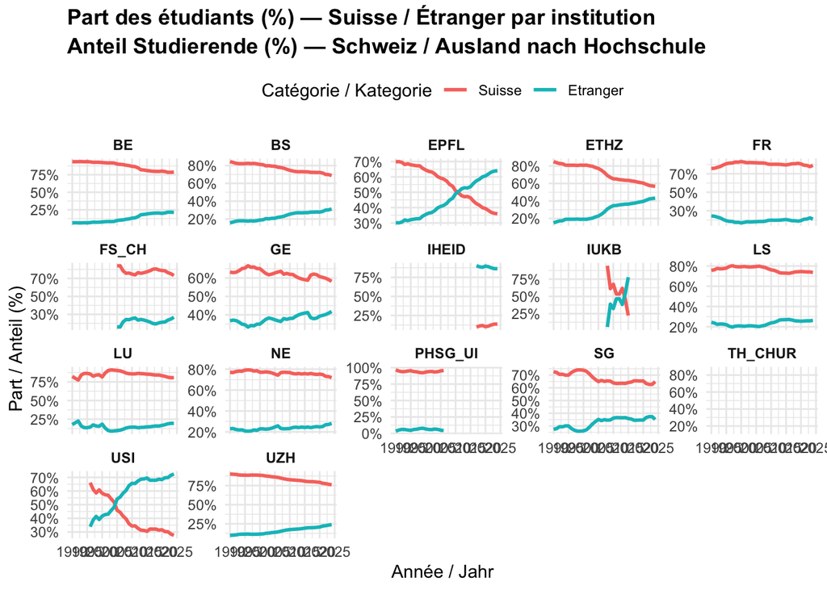

```r
library(dplyr)
library(ggplot2)
library(scales)

# 1️⃣ Calcul du pourcentage par institution et année
df_students_foreigners_pct <- df_students_foreigners_long |>
  group_by(institution, year) |>
  mutate(
    total = sum(value),
    pct = 100 * value / total
  ) |>
  ungroup()

# 2️⃣ Graphique en lignes faceté
ggplot(
  df_students_foreigners_pct,
  aes(x = year, y = pct, color = nationalite_categorie, group = nationalite_categorie)
) +
  geom_line(linewidth = 1) +
  facet_wrap(~ institution, scales = "free_y") +
  scale_x_continuous(breaks = pretty(df_students_foreigners_pct$year)) +
  scale_y_continuous(labels = label_percent(scale = 1)) +
  labs(
    title = "Part des étudiants (%) — Suisse / Étranger par institution\nAnteil Studierende (%) — Schweiz / Ausland nach Hochschule",
    x = "Année / Jahr",
    y = "Part / Anteil (%)",
    color = "Catégorie / Kategorie"
  ) +
  theme_minimal(base_size = 11) +
  theme(
    legend.position = "top",
    strip.text = element_text(face = "bold"),
    plot.title = element_text(face = "bold", lineheight = 1.1)
  )
```

#### 1.3.1 DW Small Mulitples par institutions (part de Suisses)

https://app.datawrapper.de/tamedia/edit/BV19M/upload

```r
ls_uni <- df_students_foreigners_long |>
  filter(year == max(year)) |>
  group_by(institution) |>
  summarise(value = sum(value)) |>
  slice_max(value, n = 10) |>
  pull(institution)


df_students_foreigners_ch <- df_students_foreigners_ch  |>
  mutate(
    nom_fr = "Suisse",
    nom_de = "Schweiz"
  )
```

```r
df_students_foreigners_pct |>
  left_join(institutions) |>
    filter(nationalite_categorie == "Suisse") |>
    filter(institution %in% ls_uni) |>
  select(year, nom_fr, pct) |>
  rbind(
    df_students_foreigners_ch  |>
      filter(nationalite_categorie == "Suisse") |>
      select(year, nom_fr, pct)
  ) |>
  pivot_wider(
    names_from = nom_fr,
    values_from = pct
  ) |>
    DatawRappr::dw_data_to_chart("BV19M")
```

## 2 Check dataset issu de Excel

Je regarde si les agégats des données correpondent bien au totaux de la table. Les étrangers n’y sont pas… (je les reprends de PX Web)

```r
df_evo |>
  group_by(metric, sex, year) |>
  summarise(
    total = sum(value)
  ) |>
    ungroup() |>
    view()
```

### 2.1 Indexed par cantons

```r
df_evo_indexed <- df_evo %>%
  group_by(metric, region, sex) %>%
  arrange(year) %>%
  mutate(index_base = value / first(value) * 100) %>%
  ungroup()
```

## 3 ggplot SM entrants

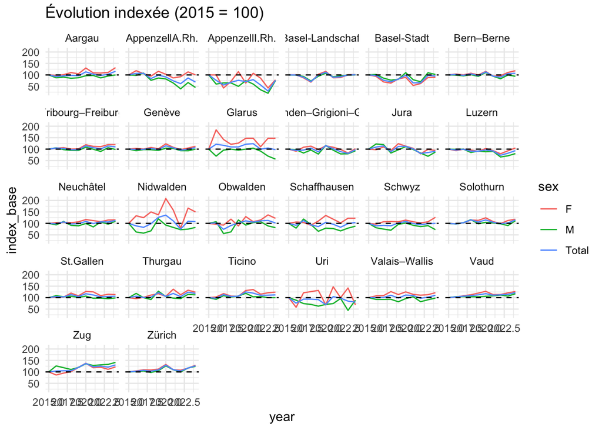

```r
# Vue d'ensemble par canton
df_evo_indexed %>%
  filter(metric == "entrants") %>%
  ggplot(aes(year, index_base, color = sex, group = interaction(region, sex))) +
  geom_line(alpha = 1) +
  geom_hline(yintercept = 100, linetype = "dashed") +
  theme_minimal() +
  facet_wrap(~region) +
  labs(title = "Évolution indexée (2015 = 100)")
```

## 4 ggplot SM étudiants

```r
gg_evo_students_canton <- df_evo_indexed %>%
  filter(metric == "etudiants_HS") %>%
  ggplot(aes(year, index_base, color = sex, group = interaction(region, sex))) +
  geom_line(alpha = 1) +
  geom_hline(yintercept = 100, linetype = "dashed") +
  theme_minimal() +
  facet_wrap(~region) +
  labs(title = "Évolution indexée (2015 = 100)")

plotly::ggplotly(gg_evo_students_canton)
```

[interactive chart not shown]

**Commentaire** Partout l’évolution des étudiantes femmes est supérieure aux hommes en 2024. Exception de Basel-Stadt et Glarus. qui ont des taux très stagnants…

### 4.1 DW SM Évolution des étudiants par cantons

https://app.datawrapper.de/tamedia/edit/LgG3A/describe

```r
df_evo_indexed %>%
  filter(metric == "etudiants_HS", sex == "Total") |>
  select(
    canton, year, index_base
  ) |>
    mutate( # transformation en tx de variation
      index_base = index_base -100
    ) |>
    pivot_wider(
      names_from = canton,
      values_from = index_base
    ) |>
      DatawRappr::dw_data_to_chart("LgG3A")
```

### 4.2 DW Carte des cantons

https://app.datawrapper.de/tamedia/edit/GWw7l/data#match

```r
id_canton <- tamMap::canton_CH()  |>
  select(
    order, iso2
  )

df_evo_indexed |>
  left_join(id_canton, by = c("canton" = "iso2")) |>
  filter(metric == "etudiants_HS") |>
  filter(year == 2025) |>
  select(canton, order, sex, index_base) |>
  mutate(index_base = index_base - 100) |>
  pivot_wider(
    names_from = "sex",
    values_from = "index_base"
  ) |>
    DatawRappr::dw_data_to_chart("GWw7l")
```

### 4.3 Commentaire

**Patterns généraux** Croissance forte (>20% en 2024-2025)

Décroissance marquée

AR : -17% → -20% AI : -23% → -24% UR : -18% (stabilisé depuis 2022)

Stabilité relative

SG, TG, LU : variations modérées (<6%)

Points d’intérêt

Rupture 2020-2021 : accélération brutale dans plusieurs cantons (VD +5% → +10%, ZH +10% → +17%, ZG +7% → +14%) Contrastes urbain-rural : les cantons urbains/universitaires (VD, ZH, ZG, GE) explosent, les petits cantons alpins (AI, UR, AR) perdent des étudiants 2024-2025 : nouvelle accélération dans certains cantons (VD, ZG)

### 4.4 Import données financières

https://www.pxweb.bfs.admin.ch/pxweb/fr/px-x-1506030100_203/px-x-1506030100_203/px-x-1506030100_203.px/table/tableViewLayout2/

```r
url <- "https://www.pxweb.bfs.admin.ch/sq/e6157caf-559c-443a-b9eb-24a3d468cce4"
chemin_local <- input_raw_dir
nom_fichier <- "px_finances.csv"

# get_px(url, chemin_local, nom_fichier)

df_finances <- read_csv(file.path(chemin_local, nom_fichier)) %>%
janitor::clean_names()
```

#### 4.4.1 Clean finances

```r
df_finances_long <- df_finances |>
  rename(
    year = annee
  ) |>
  pivot_longer(
    cols = haute_ecole_total:autres_iu,
    names_to = "institution",
    values_to = "costs"
  ) |>
    mutate(
      institution = toupper(institution)
      )

unique(df_finances_long$prestation)
```

```
[1] "Enseignement: études de base"        "Enseignement: formation approfondie"
[3] "Recherche et développement (RD)"     "Formation continue"
[5] "Prestations de service"
```

```r
# [1] "Enseignement: études de base"        "Enseignement: formation approfondie" "Recherche et développement (RD)"
# [4] "Formation continue"                  "Prestations de service"
```

#### 4.4.2 Total costs

```r
df_finances_long_total_costs <- df_finances_long |>
  group_by(institution, year) |>
  summarise(
    total_costs = sum(costs, na.rm = TRUE)
  )
```

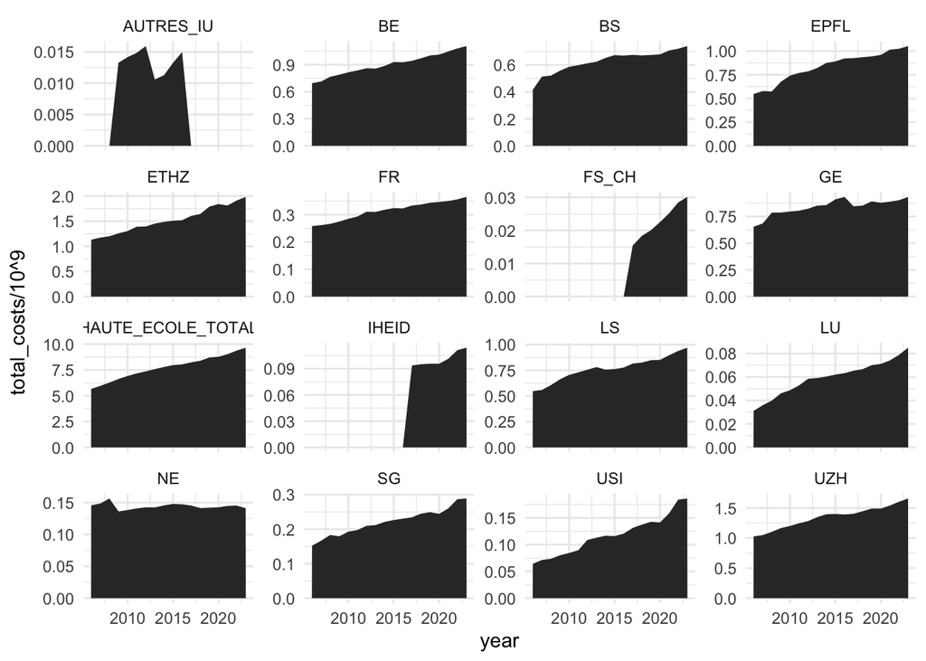

```r
ggplot(df_finances_long_total_costs, aes(x = year, y = total_costs / 10^9)) +
  geom_area() +
  facet_wrap(vars(institution), scales = "free_y") # "fixed")
```

#### 4.4.3 R&D

```r
df_finances_r_and_d <- df_finances_long |>
  filter(prestation == "Recherche et développement (RD)")
```

#### 4.4.4 Chart R&D

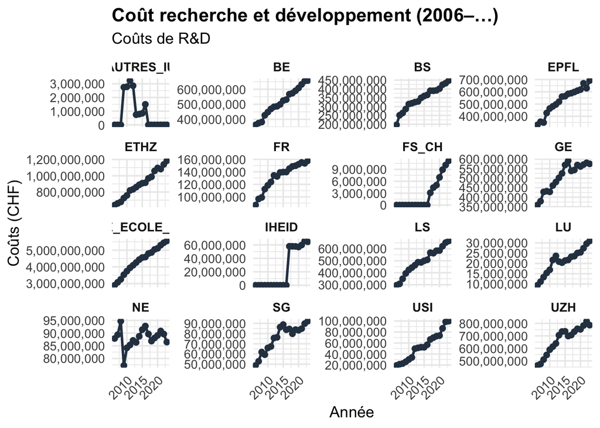

```r
ggplot(df_finances_r_and_d,
       aes(x = year, y = costs)) +
  geom_line(linewidth = 1, color = "#2C3E50") +
  geom_point(size = 2, color = "#2C3E50") +
  facet_wrap(~ institution, scales = "free_y") +
  scale_y_continuous(labels = scales::comma_format()) +
  labs(
    title = "Coût recherche et développement (2006–…)",
    subtitle = "Coûts de R&D",
    x = "Année",
    y = "Coûts (CHF)"
  ) +
  theme_minimal(base_size = 13) +
  theme(
    strip.text = element_text(face = "bold"),
    plot.title = element_text(face = "bold"),
    axis.text.x = element_text(angle = 45, hjust = 1)
  )
```

#### 4.4.5 Chart ranking

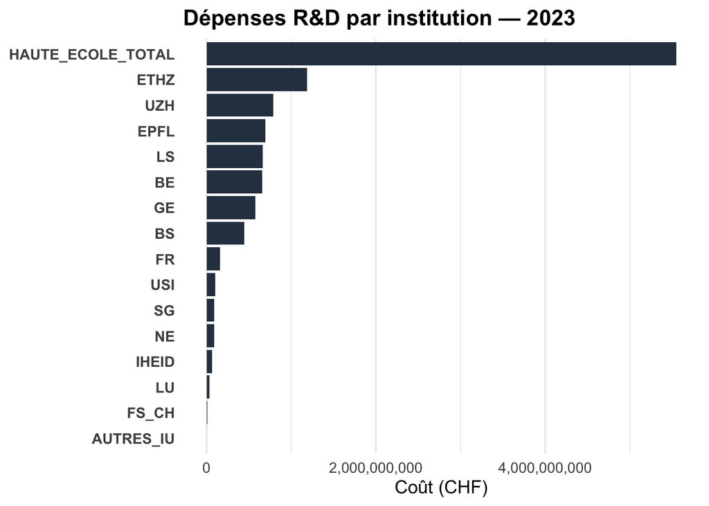

```r
ggplot(
  df_finances_r_and_d |>
    filter(year == max(year, na.rm = TRUE)),
  aes(x = costs, y = reorder(institution, costs))
) +
  geom_col(fill = "#2C3E50") +
  # coord_flip() +
  scale_x_continuous(labels = scales::comma_format()) +
  labs(
    title = paste("Dépenses R&D par institution —", max(df_finances_r_and_d$year, na.rm = TRUE)),
    x = "Coût (CHF)",
    y = NULL
  ) +
  theme_minimal(base_size = 13) +
  theme(
    plot.title = element_text(face = "bold"),
    axis.text.y = element_text(face = "bold"),
    panel.grid.major.y = element_blank()
  )
```

#### 4.4.6 Teaching costs

```r
df_teaching_costs <- df_finances_long |>
  filter(prestation  %in% c("Enseignement: études de base","Enseignement: formation approfondie")) |>
  group_by(institution, year) |>
  summarise(
    teaching_costs = sum(costs, na.rm = TRUE)
  )

df_students_costs_institution <- df_students_foreigners_long |>
  group_by(year, institution) |>
  summarise(
    students = sum(value)
  )  |>
    ungroup() |>
    left_join(df_teaching_costs) |>
    filter(year >= 2006) |>
    mutate(
      cost_per_student = teaching_costs / students
    )
```